# Lab 2

STA 206 | Fall 2022

October 3, 2022

Fitting a simple linear regression model may seem easy and intuitive. But when the data set is large, doing the calculation manually gets tedious and may become impractical. Here, we will learn how we can use R to make things a lot easier.

## Reading data into R

Let’s consider the *Copier maintenance* data. X denotes the number of copiers serviced, and Y denotes the number of minutes spent by the service person. We have data on 45 locations. We want to fit a simple regression model (this Lab) and examine whether it is appropriate (next Lab).

Save the data file (Copier.txt) to your local drive and remember the location/path of your file.

```r
##### Set working directory
setwd("D:/fall 2020/STA 206/Lab 2")
##Alternatively, use the "Session" menu of R studio
```

Then, read the data:

```r
##### Read in data
copier = read.table("Copier.txt", header=FALSE)
```

We have now defined a *data frame* called **copier** and imported the dataset saved in “Copier.txt” into this data frame. Notice here “header=FALSE” means that in the text file “Copier.txt”, there is no variable name in the “header” (the first row is data instead of variable name). If the text file contained variable names, we would have changed to “header=TRUE”.

If we had a csv file, we would use “read.csv”.

```r
copier = read.csv("Copier.csv", header=FALSE)
```

We can examine this object using *class* and *str* functions:

```r
class(copier)
```

```
## [1] "data.frame"
```

```r
str(copier)
```

```
## 'data.frame':    45 obs. of  2 variables:
##  $ V1: int  20 60 46 41 12 137 68 89 4 32 ...
##  $ V2: int  2 4 3 2 1 10 5 5 1 2 ...
```

We can have a quick examination of the data using *head*, *summary*, etc., functions in R.

```r
head(copier)
```

```
##    V1 V2
## 1  20  2
## 2  60  4
## 3  46  3
## 4  41  2
## 5  12  1
## 6 137 10
```

```r
summary(copier)
```

```
##        V1               V2
##  Min.   :  3.00   Min.   : 1.000
##  1st Qu.: 36.00   1st Qu.: 2.000
##  Median : 74.00   Median : 5.000
##  Mean   : 76.27   Mean   : 5.111
##  3rd Qu.:111.00   3rd Qu.: 7.000
##  Max.   :156.00   Max.   :10.000
```

We can examine the data type of each variable by applying the *class* function to each variable:

```r
sapply(copier, class)
```

```
##        V1        V2
## "integer" "integer"
```

## Running Simple Linear Regression Using *lm* Function

Now that data was read into R, we can see the two columns are automatically named V1 and V2 respectively. V1 is number of minutes spent by service person (Y), and V2 is the number of copier machines (X). In the *lm* function, the response variable should be on the left side of the formula, and the X variable(s) should be on the right side of the formula. We are essentially fitting the model $Y = \beta_0 + \beta_1 X + \epsilon$.

```r
##### Fitting
fit = lm(V1~V2, data=copier)
summary(fit)
```

```
##
## Call:
## lm(formula = V1 ~ V2, data = copier)
##
## Residuals:
##      Min       1Q   Median       3Q      Max
## -22.7723  -3.7371   0.3334   6.3334  15.4039
##
## Coefficients:
##             Estimate Std. Error t value Pr(>|t|)
## (Intercept)  -0.5802     2.8039  -0.207    0.837
## V2           15.0352     0.4831  31.123   <2e-16 ***
## ---
## Signif. codes:  0 '***' 0.001 '**' 0.01 '*' 0.05 '.' 0.1 ' ' 1
##
## Residual standard error: 8.914 on 43 degrees of freedom
## Multiple R-squared:  0.9575, Adjusted R-squared:  0.9565
## F-statistic: 968.7 on 1 and 43 DF,  p-value: < 2.2e-16
```

## Inference of Regression Coefficients

Suppose we want to test if the number of copier machines is significant in predicting the number of minutes spent by service person at significance level $0.05$:

$$H_0: \beta_1 = 0 \; vs \; H_1: \beta_1
\neq 0$$
We can calculate the test statistic

$$T = \frac{\hat{\beta}_1 -
0}{s(\hat{\beta}_1)}$$

```r
output = summary(fit)$coef
output
```

```
##               Estimate Std. Error    t value     Pr(>|t|)
## (Intercept) -0.5801567  2.8039411 -0.2069076 8.370587e-01
## V2          15.0352480  0.4830872 31.1232581 4.009032e-31
```

```r
test1 = output[2,1]/output[2,2]
qt(0.975, df = 43)
```

```
## [1] 2.016692
```

**Question**: What is the conclusion? Why we are computing t(0.975;43)?

**Question**: How to test whether $\beta_1>0$ or not at significance level $0.05$? What is your conclusion?

**Exercise**: Carry out a similar test for $\beta_0$ and draw conclusion.

We can also directly read the T-tests results from the *summary* output. The standard errors of the estimators are also given in the *summary* output.  
The “Multiple R-squared” in the *summary* output is the coefficient of determination, which is 0.9575 here. The “Residual standard error” in the output gives the square root of MSE: So here MSE = $8.914^2 = 79.459$.

With the information given in the *summary* output, one should be able to construct confidence intervals for $\beta_0$ and $\beta_1$. For example, a 95% confidence interval for $\beta_1$ is

$$\hat{\beta}_1 \pm t(1-\alpha/2;
n-2)*s(\hat{\beta}_1) = 15.0352 \pm 0.9743$$

```r
15.0352 - qt(0.975,43) * 0.4831  # lower bound of 95% confidence interval for beta_1
```

```
## [1] 14.06094
```

```r
15.0352 + qt(0.975,43) * 0.4831  # upper bound of 95% confidence interval for beta_1
```

```
## [1] 16.00946
```

**Exercise**: Construct a 90% confidence interval for $\beta_0$.

To see the LS estimator, residuals or fitted values we can use the following functions:

```r
coef(fit)
```

```
## (Intercept)          V2
##  -0.5801567  15.0352480
```

```r
fit$coefficients
```

```
## (Intercept)          V2
##  -0.5801567  15.0352480
```

```r
residuals(fit)
```

```
##           1           2           3           4           5           6
##  -9.4903394   0.4391645   1.4744125  11.5096606  -2.4550914 -12.7723238
##           7           8           9          10          11          12
##  -6.5960836  14.4039164 -10.4550914   2.5096606   9.2629243   6.2276762
##          13          14          15          16          17          18
##   3.3686684  -8.5255875  12.4391645 -19.7018277   0.3334204  11.2981723
##          19          20          21          22          23          24
## -22.7723238  -2.5608355  -8.5960836  -3.6665796   4.3334204  -0.5960836
##          25          26          27          28          29          30
##  -0.7370757   7.3334204 -11.4903394  -1.5960836   6.3334204   6.3686684
##          31          32          33          34          35          36
##   3.2981723  15.4039164  -9.4903394  -1.4903394 -11.4550914  -2.5608355
##          37          38          39          40          41          42
##  11.4039164  -2.7370757   7.3334204  12.5449086  -3.7370757   4.5096606
##          43          44          45
##  -2.4903394   1.4391645   2.4039164
```

```r
fit$residuals ##or equivalently
```

```
##           1           2           3           4           5           6
##  -9.4903394   0.4391645   1.4744125  11.5096606  -2.4550914 -12.7723238
##           7           8           9          10          11          12
##  -6.5960836  14.4039164 -10.4550914   2.5096606   9.2629243   6.2276762
##          13          14          15          16          17          18
##   3.3686684  -8.5255875  12.4391645 -19.7018277   0.3334204  11.2981723
##          19          20          21          22          23          24
## -22.7723238  -2.5608355  -8.5960836  -3.6665796   4.3334204  -0.5960836
##          25          26          27          28          29          30
##  -0.7370757   7.3334204 -11.4903394  -1.5960836   6.3334204   6.3686684
##          31          32          33          34          35          36
##   3.2981723  15.4039164  -9.4903394  -1.4903394 -11.4550914  -2.5608355
##          37          38          39          40          41          42
##  11.4039164  -2.7370757   7.3334204  12.5449086  -3.7370757   4.5096606
##          43          44          45
##  -2.4903394   1.4391645   2.4039164
```

```r
fitted(fit)
```

```
##         1         2         3         4         5         6         7         8
##  29.49034  59.56084  44.52559  29.49034  14.45509 149.77232  74.59608  74.59608
##         9        10        11        12        13        14        15        16
##  14.45509  29.49034 134.73708 149.77232  89.63133  44.52559  59.56084 119.70183
##        17        18        19        20        21        22        23        24
## 104.66658 119.70183 149.77232  59.56084  74.59608 104.66658 104.66658  74.59608
##        25        26        27        28        29        30        31        32
## 134.73708 104.66658  29.49034  74.59608 104.66658  89.63133 119.70183  74.59608
##        33        34        35        36        37        38        39        40
##  29.49034  29.49034  14.45509  59.56084  74.59608 134.73708 104.66658  14.45509
##        41        42        43        44        45
## 134.73708  29.49034  29.49034  59.56084  74.59608
```

```r
fit$fitted
```

```
##         1         2         3         4         5         6         7         8
##  29.49034  59.56084  44.52559  29.49034  14.45509 149.77232  74.59608  74.59608
##         9        10        11        12        13        14        15        16
##  14.45509  29.49034 134.73708 149.77232  89.63133  44.52559  59.56084 119.70183
##        17        18        19        20        21        22        23        24
## 104.66658 119.70183 149.77232  59.56084  74.59608 104.66658 104.66658  74.59608
##        25        26        27        28        29        30        31        32
## 134.73708 104.66658  29.49034  74.59608 104.66658  89.63133 119.70183  74.59608
##        33        34        35        36        37        38        39        40
##  29.49034  29.49034  14.45509  59.56084  74.59608 134.73708 104.66658  14.45509
##        41        42        43        44        45
## 134.73708  29.49034  29.49034  59.56084  74.59608
```

```r
fitted(fit)[5]  # fifth fitted value
```

```
##        5
## 14.45509
```

```r
residuals(fit)[5]   # fifth residual
```

```
##         5
## -2.455091
```

To see the anova table we can use the **anova** function.

```r
anova(fit)
```

```
## Analysis of Variance Table
##
## Response: V1
##           Df Sum Sq Mean Sq F value    Pr(>F)
## V2         1  76960   76960  968.66 < 2.2e-16 ***
## Residuals 43   3416      79
## ---
## Signif. codes:  0 '***' 0.001 '**' 0.01 '*' 0.05 '.' 0.1 ' ' 1
```

## Finding Confidence and Prediction Intervals

You can compute confidence intervals for mean response and make prediction intervals for new data using the *predict* function. We can see a prediction interval for a new observation is wider than the corresponding confidence interval for the mean response.

```r
##### Finding Prediction intervals
newX=data.frame(V2=5)
# interval specifies the type of intervals you want to obtain
# level specifies the confidence level
predict(fit, newX, interval='confidence', level=0.95)
```

```
##        fit      lwr      upr
## 1 74.59608 71.91422 77.27794
```

```r
predict(fit, newX, interval='confidence', level=0.99)
```

```
##        fit      lwr      upr
## 1 74.59608 71.01205 78.18011
```

```r
predict(fit, newX, interval='prediction', level=0.95)
```

```
##        fit      lwr      upr
## 1 74.59608 56.42133 92.77084
```

```r
predict(fit, newX, interval='prediction', level=0.99)
```

```
##        fit      lwr      upr
## 1 74.59608 50.30738 98.88478
```

## Saving and Loading

To save the least squares model, simply type the following and give a file name easy to remember:

```r
save(fit,file='copier_fit.RData')
```

To load this saved file in the future, you need to open R console first, then double click on this file. Or, you can also type

```r
load("copier_fit.RData")
```

You can also save the entire R space by

```r
save.image(file="copier_all.RData")
```

## More about R plotting

Here we go into more details about R plotting. More materials can be found in http://www.harding.edu/fmccown/r/. First we’ll produce a very simple graph using the values in the *cars* vector. Let’s add a title, a line to connect the points, and some color:

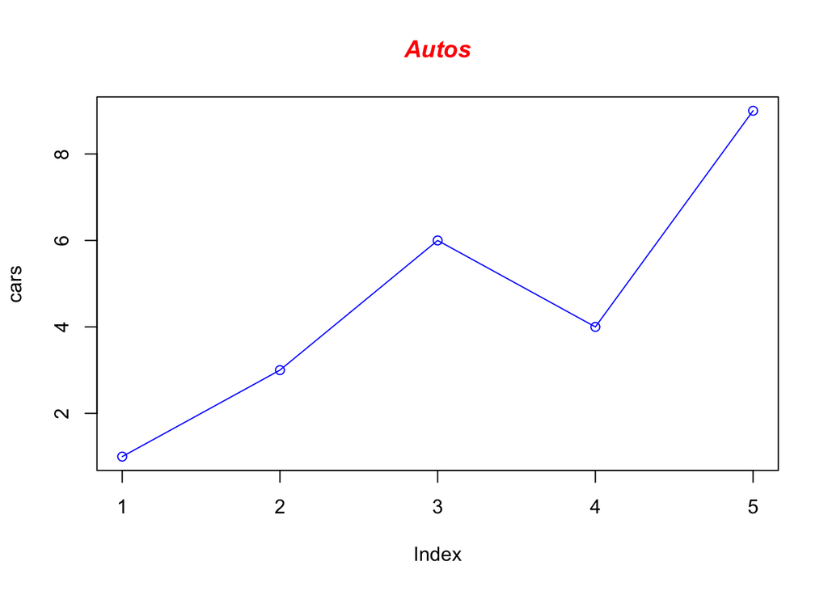

```r
# Define the cars vector with 5 values
cars <- c(1, 3, 6, 4, 9)

# Graph cars using blue points overlayed by a line
plot(cars, type="o", col="blue")

# Create a title with a red, bold/italic font
title(main="Autos", col.main="red", font.main=4)
```

Now let’s add a red line for trucks and specify the y-axis range directly so it will be large enough to fit the truck data:

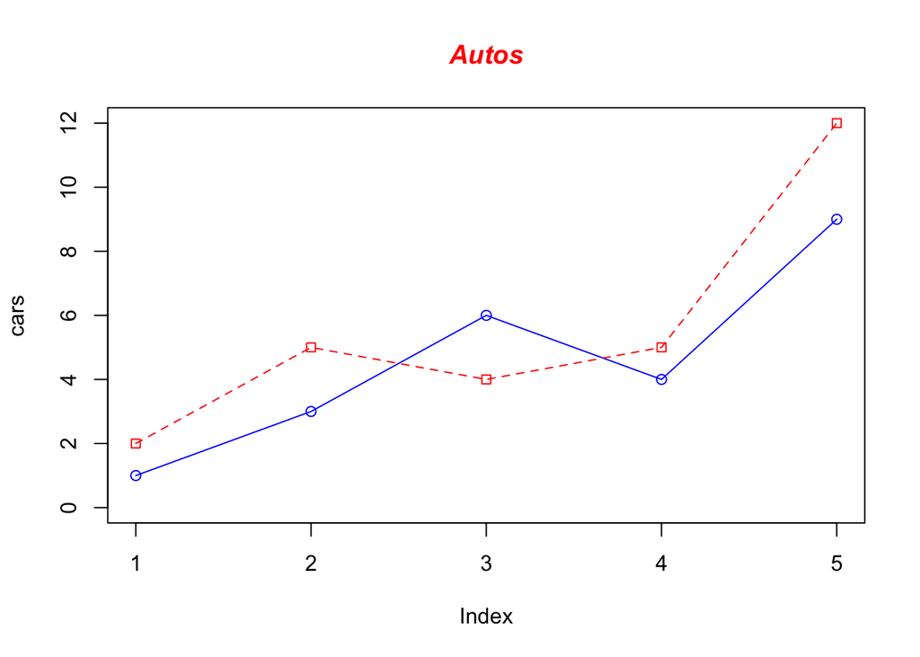

```r
# Define 2 vectors
cars <- c(1, 3, 6, 4, 9)
trucks <- c(2, 5, 4, 5, 12)

# Graph cars using a y axis that ranges from 0 to 12
plot(cars, type="o", col="blue", ylim=c(0, 12))

# Graph trucks with red dashed line and square points
lines(trucks, type="o", pch=22, lty=2, col="red")

# Create a title with a red, bold/italic font
title(main="Autos", col.main="red", font.main=4)
```

Next let’s change the axes labels to match our data and add a legend. We’ll also compute the y-axis values using the max function so any changes to our data will be automatically reflected in our graph.

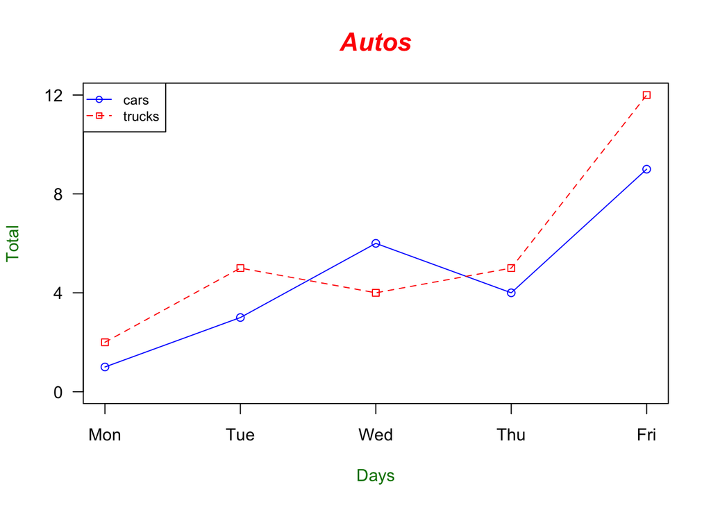

```r
# Define 2 vectors
cars <- c(1, 3, 6, 4, 9)
trucks <- c(2, 5, 4, 5, 12)

# Calculate range from 0 to max value of cars and trucks
g_range <- range(0, cars, trucks)

# Graph autos using y axis that ranges from 0 to max
# value in cars or trucks vector. Turn off axes and
# annotations (axis labels) so we can specify them ourself

#png('cars_plot.png')###save the plot

plot(cars, type="o", col="blue", ylim=g_range,
axes=FALSE, ann=FALSE)

# Make x axis using Mon-Fri labels
axis(1, at=1:5, lab=c("Mon","Tue","Wed","Thu","Fri"))

# Make y axis with horizontal labels that display ticks at
# every 4 marks. 4*0:g_range[2] is equivalent to c(0,4,8,12).
axis(2, las=1, at=4*0:g_range[2])

# Create box around plot
box()

# Graph trucks with red dashed line and square points
lines(trucks, type="o", pch=22, lty=2, col="red")

# Create a title with a red, bold/italic font, and slightly larger
title(main="Autos", col.main="red", font.main=4, cex.main=1.5)

# Label the x and y axes with dark green text
title(xlab="Days", col.lab=rgb(0,0.5,0))
title(ylab="Total", col.lab=rgb(0,0.5,0))

# Create a legend at topleft that is slightly smaller
# (cex) and uses the same line colors and points used by
# the actual plots
legend("topleft", c("cars","trucks"), cex=0.8,
col=c("blue","red"), pch=c(21,22), lty=c(1,2))
```

Change points and label size:

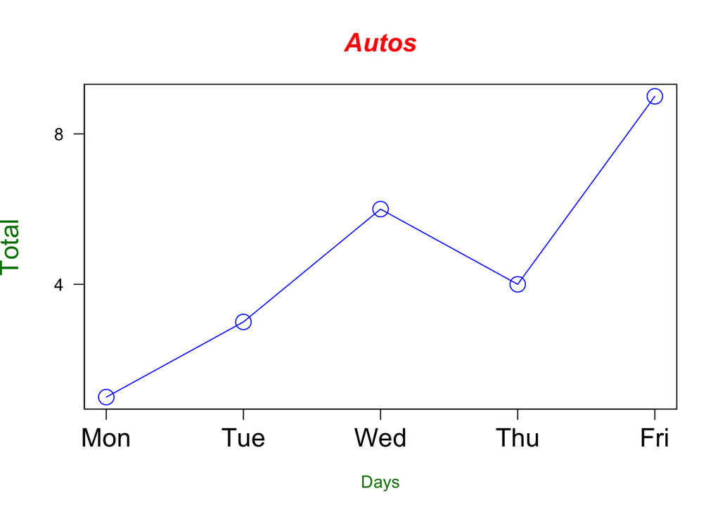

```r
plot(cars, type="o", col="blue", axes = FALSE, ann = FALSE, cex = 2)
##cex changes the point size

title(main="Autos", col.main="red", font.main=4, cex.main=1.5)
axis(1, at=1:5, lab=c("Mon","Tue","Wed","Thu","Fri"), cex.axis = 1.5)
##cex.axis changes the axis tick marks size
axis(2, las=1, at=4*0:g_range[2])

title(xlab="Days", col.lab=rgb(0,0.5,0))
title(ylab="Total", col.lab=rgb(0,0.5,0), cex.lab = 1.5)
##cex.lab changes the axis labels

box()
```